# PD2 - raport

Filimonow Dominika

2023-03-20

# **Wstęp**

Zadanie polegało na odszukaniu, a następnie poprawieniu wybranej wizualizacji danych dostępnej w mediach, opublikowanej w ciągu ostatnich dwóch tygodni.

## **Wybrana wizualizacja**

Wykres, który zdecydowałam się zmodyfikować, pochodzi z profilu premiera Mateusza Morawieckiego na portalu społecznościowym Facebook i przedstawia liczbę mieszkań oddanych do użytkowania w latach 2008-2022. Post został opublikowany 14 marca 2023.

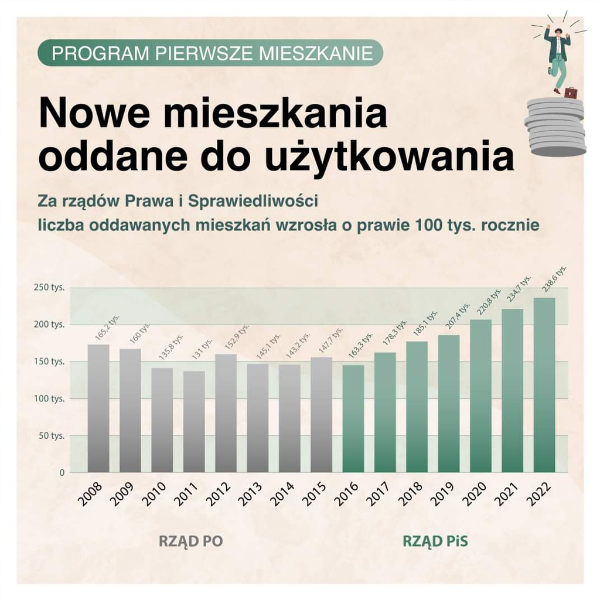

*Źródło: Mateusz Morawiecki, “Nowe mieszkania oddane do użytkowania”, https://www.facebook.com/MorawieckiPL, 14.03.2023, https://m.facebook.com/story.php?story_fbid=pfbid02PPQdpz66dm2XgXcKxgLEvPtxDZMzmmWMifPmYw2yoprm8DMFe1x3uWYfEyqA6Dbtl&id=100044431989580&sfnsn=mo*

# **Wprowadzone zmiany**

### - Poprawa wysokości słupków i ich zgodności z osią Y

Na oryginalnym wykresie podane wartości nie zgadzały się z podziałkami oraz wysokościami słupków. Przykładowo w roku 2015 liczba oddanych mieszkań wyniosła *147,7 tys.*, zaś w roku następnym *163,3 tys.*, natomiast słupkek odpowiadający rokowi 2016 jest wyraźnie mniejszy od tego z 2015. Innym przykładem jest rok 2019, w którym liczba oddanych mieszkań przekroczyła *200 tys.*, jednak z podziałki na osi Y wynika, że liczba ta była mniejsza.

### - Zamiana koloru

Szary kolor użyty na wykresie w latach 2008-2015 nie wyróżnia się. Patrząc na wizualizację, cała uwaga odbiorcy skupia się wyłącznie na połowie wykresu. Szarość została zastąpiona żywszym kolorem by ta uwaga rozłożona była bardziej równomiernie.

## Kod tworzonej wizualizacji

```r
#z odczytanych danych utworzyłam plik csv, na którego podstawie wygeneruję nowy wykres
wartosci <- read.csv("dane.csv")

Wykres <- ggplot(wartosci, aes(x = Rok, y = Wartosc, fill = factor(ifelse(Rok >= 2016,"RZĄD PiS","RZĄD PO")))) +
  labs(title = "Nowe mieszkania
oddane do użytkowania") +
  theme(plot.title = element_text(face = "bold", size = 20)) +
  theme(legend.position = "bottom") +
  theme(legend.spacing.x = unit(1, 'cm'))+
  scale_fill_manual(name = "", values=c("#ff8400", "#008720"), breaks=c('RZĄD PO', 'RZĄD PiS'))+
  scale_x_continuous("", labels = as.character(wartosci$Rok), breaks = wartosci$Rok)+
  scale_y_continuous("Liczba oddanych mieszkań (w tys.)")+
  geom_col()+
  geom_text(aes(label = Wartosc), vjust = -0.2, size = 3, color = factor(ifelse(wartosci$Rok >= 2016,"#008720","#ff8400")))
```

# **Gotowa wizualizacja**

Tak prezentuje się poprawiony wykres.

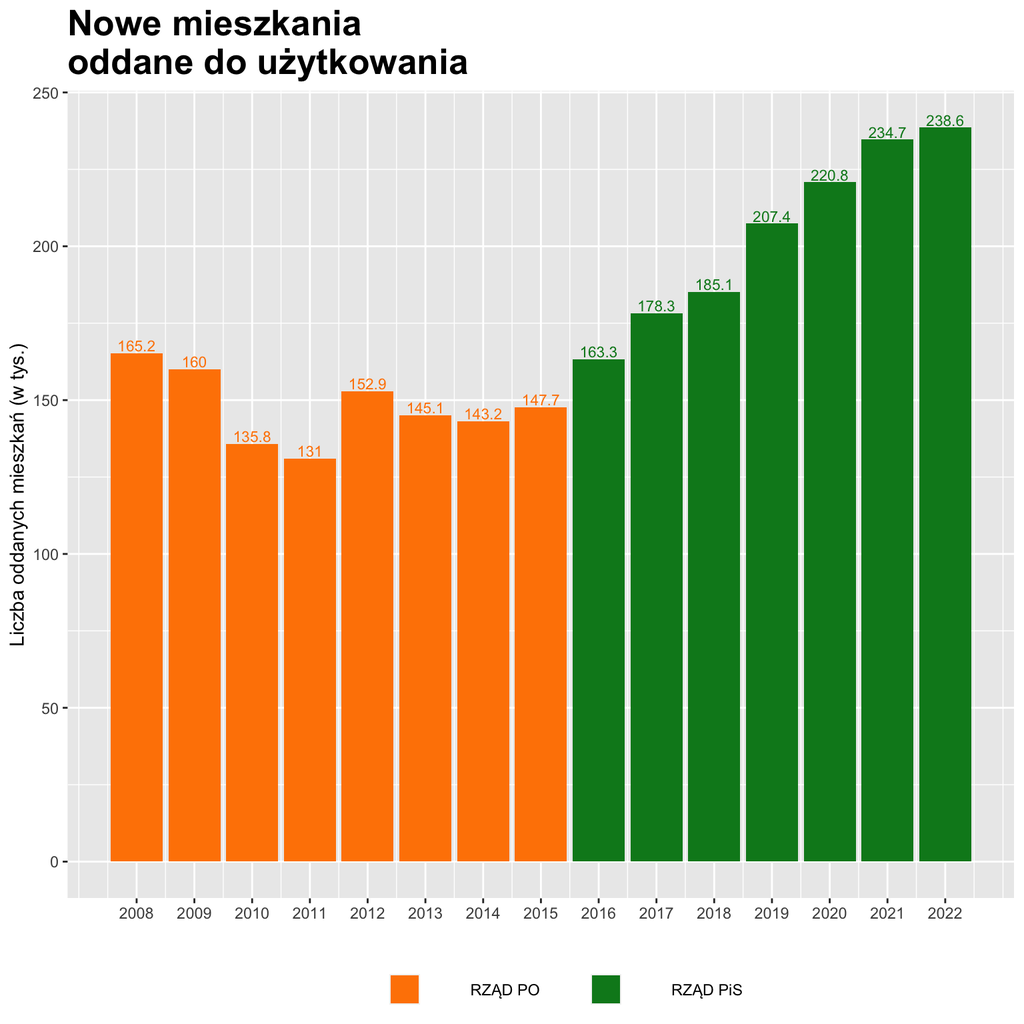

# **Podsumowanie**

W uzyskanym wykresie słupki zgadzają się z podziałką na osi Y, ponadto ich wysokość jest zgodna z przypisanymi im wartościami. Ponadto obie części wykresu przykuwają uwagę, bez faworyzacji żadnej połowy. Wobec tego otrzymany wykres jest lepszy od oryginału.